# R Bootcamp Assignment: Prediction of the price of second hand cars

## 5.4 Use predefined graphs

In another example we use a pre-defined data set *karate*, which is delivered with the package “igraphdata”. The data set already belongs to the igraph class and can therefore already be visualized with the plot() function.

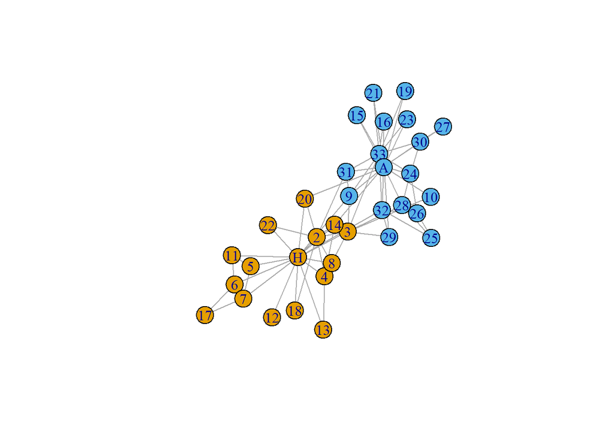

```r
data("karate")
plot(karate)
```

## 5.5 A short closing word on graphs and further interesting graph-packages

Graphs provide a structure to store data. In contrast to relational databases not only the entities but also the relations are given importance. So graphs are a powerful tool for data storage and allow strong queries, which would not be possible in relational environments at all or can only be reached very laboriously via many joins.

A typical application example is social media. But there are also several other possibilities to use graphs. Very interesting are, for example, the interests of website visitors, which can be easily connected by means of graphs, for example to be able to design and deliver advertising very individually.

Other exciting packages for graph modeling and analysis are:

- *tidygraph*: With tidygraph, network objects like graphs and edges are stored similar to tibbles and data.frames. Thus the data preparation and transformation functions of dplyr can be used.
- *ggraph*: As the name of this package suggests, ggraph brings the visualization of graphs into the same form as ggplot2.
- *visnetwork and network3D*: visNetwork and network3D allow to create interactive graphs.